# Assignment Web APIs

2024-10-29

## Working with Purrr

In this sample vignette, I will walk through some of the functionalities of the the *purrr* Tidyverse package using an [agriculture dataset](https://www.kaggle.com/datasets/bhadramohit/agriculture-and-farming-dataset) from Kaggle.

According the [Tidyverse](https://purrr.tidyverse.org) site, purrr “enhances R’s functional programming (FP) toolkit by providing a complete and consistent set of tools for working with functions and vectors.” It replaces a conventional “for loop” with a collection of functions centered around the *map* function to introduce an easy-to-read, compact syntax, that is powerful and performant.

In this tutorial, I will go over the following functions - map - map_* family - map2 - pmap

Before we get started, lets read in our csv file and prep the *farm_data* dataframe.

```r
#setwd("")
farm_data <- read.csv('https://raw.githubusercontent.com/mcastro64/d607-assignments/refs/heads/master/assignment-07/agriculture_dataset.csv') %>%
  rename_all(~str_to_lower(.)) %>%    # Convert all column names to lowercase
  rename_all(~str_replace_all(., "\\.", "_")) %>% # Replace spaces with underscore
  rename_all(~str_replace_all(., "_$", "")) # remove trailing _

glimpse(farm_data)
```

```
## Rows: 50
## Columns: 10
## $ farm_id                  <chr> "F001", "F002", "F003", "F004", "F005", "F006…
## $ crop_type                <chr> "Cotton", "Carrot", "Sugarcane", "Tomato", "T…
## $ farm_area_acres          <dbl> 329.40, 18.67, 306.03, 380.21, 135.56, 12.50,…
## $ irrigation_type          <chr> "Sprinkler", "Manual", "Flood", "Rain-fed", "…
## $ fertilizer_used_tons     <dbl> 8.14, 4.77, 2.91, 3.32, 8.33, 6.42, 1.83, 5.1…
## $ pesticide_used_kg        <dbl> 2.21, 4.36, 0.56, 4.35, 4.48, 2.25, 2.37, 0.9…
## $ yield_tons               <dbl> 14.44, 42.91, 33.44, 34.08, 43.28, 38.18, 44.…
## $ soil_type                <chr> "Loamy", "Peaty", "Silty", "Silty", "Clay", "…
## $ season                   <chr> "Kharif", "Kharif", "Kharif", "Zaid", "Zaid",…
## $ water_usage_cubic_meters <dbl> 76648.20, 68725.54, 75538.56, 45401.23, 93718…
```

### Using *map*

The *map* function makes a list by passing a list or an atomic verctor and a function as parameters in the format **map(.x, .f)**, where .x is our list/vector and .f is our function.

In example 1, we want to use Prrr to calculate the mean for the numerical columns of our sample dataframe. We first pass the dataframe to the **dplyr** function *“select”*, then use *“where”* to select the correct columns using *is.numeric* to return only the columns with numeric values. We can then pass this list into the *map* function using the .x parameter and pass function “mean” using the .f parameter. Example 2 shows an abbreviated version of the same calculation.

**Example 1**

```r
ex1_list <- farm_data |>
  select(where(is.numeric))

map(.x = ex1_list, .f = mean)
```

```
## $farm_area_acres
## [1] 254.9638
##
## $fertilizer_used_tons
## [1] 4.9054
##
## $pesticide_used_kg
## [1] 2.398
##
## $yield_tons
## [1] 27.0592
##
## $water_usage_cubic_meters
## [1] 56724.3
```

**Example 2**

```r
ex2_list <- farm_data |>
  select(where(is.numeric)) |>
  map(mean)

ex2_list
```

```
## $farm_area_acres
## [1] 254.9638
##
## $fertilizer_used_tons
## [1] 4.9054
##
## $pesticide_used_kg
## [1] 2.398
##
## $yield_tons
## [1] 27.0592
##
## $water_usage_cubic_meters
## [1] 56724.3
```

### Using other functions in the *map**_ family

In addition to the *map* function that returns a list, Purrr has dedicated functions that return specific vector types. Each functions named with the “map_” prefix followed by an abbreviation of the vector type, as seen in Example 3.

- map_lgl() returns a logical vector
- map_int() returns an integer vector
- map_dbl() returns a double vector
- map_chr() returns a character vector

**Example 3**

```r
farm_area_miles <- map_dbl(farm_data$farm_area_acres, function(.x) {
  return(.x/640)
})

farm_area_miles
```

```
##  [1] 0.51468750 0.02917188 0.47817187 0.59407813 0.21181250 0.01953125
##  [7] 0.56259375 0.72593750 0.60839062 0.28807813 0.43742187 0.22706250
## [13] 0.51421875 0.38440625 0.47679687 0.09409375 0.44376562 0.20035937
## [19] 0.72020313 0.09195312 0.58914062 0.14479687 0.02448437 0.75606250
## [25] 0.11818750 0.25356250 0.58609375 0.40029687 0.45081250 0.44768750
## [31] 0.21275000 0.54753125 0.69806250 0.41268750 0.41567187 0.69712500
## [37] 0.24390625 0.67378125 0.34450000 0.26065625 0.57935938 0.65467188
## [43] 0.12310938 0.13143750 0.51045312 0.17625000 0.54321875 0.12092187
## [49] 0.72245313 0.45664063
```

### Returning a Dataframe

Purr can also return a dataframe using the *map_df* function. Example 4 modifies the *map_dbl* example to return a dataframe of farm area in acres and miles. This example also uses an inline funciton notation whose variable **.x** represents the rows of the data variable (“farm_data$farm_area_acres”) that was passed into the *map_df* functions. The function returns a data frame.

**Example 4**

```r
map_area_df <- map_df(farm_data$farm_area_acres, function(.x) {
  return(data.frame(acres = .x, miles = .x/640))
})

map_area_df
```

```
##     acres      miles
## 1  329.40 0.51468750
## 2   18.67 0.02917188
## 3  306.03 0.47817187
## 4  380.21 0.59407813
## 5  135.56 0.21181250
## 6   12.50 0.01953125
## 7  360.06 0.56259375
## 8  464.60 0.72593750
## 9  389.37 0.60839062
## 10 184.37 0.28807813
## 11 279.95 0.43742187
## 12 145.32 0.22706250
## 13 329.10 0.51421875
## 14 246.02 0.38440625
```

[output cut: 36 more lines]

### Handling multiple inputs

Purrr also has two functions for handling more than 1 list at a time: - *map2*- applies a function to two elements - *pmap*- applies a function to a list of elements

** Working with *map2***

Example 4 shows how to work with *map2*. We pass two lists into variables .x and .y. These variables are then passed into the function when initializing it and manipulated within its body. The function returns a list.

**Example 4**

```r
# map2 example
map2_ex <- map2(.x = farm_data$yield_tons, .y = farm_data$farm_area_acres, function(.x, .y) {
  return(.x /.y)
})

# print type and first 3 rows
class(map2_ex)
```

```
## [1] "list"
```

```r
print(map2_ex[1:3])
```

```
## [[1]]
## [1] 0.04383728
##
## [[2]]
## [1] 2.29834
##
## [[3]]
## [1] 0.1092703
```

**Working with *pmap***

**Example 5**

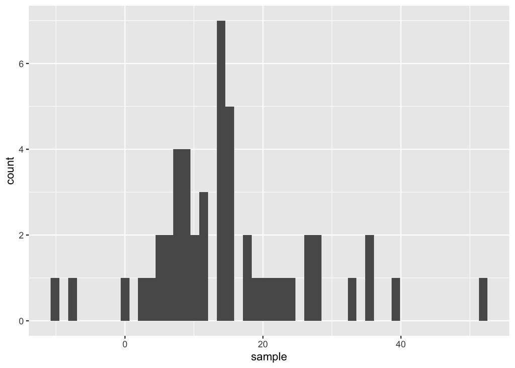

```r
# construct list for this example
calcs_list <- farm_data |>
  group_by(crop_type) |>
  mutate(
    means = mean(yield_tons),
    sds = sd(yield_tons),
    samplesize = 50
  ) |>
  subset(select=c(means, sds, samplesize))

# pmap_example
set.seed(1234)
pmap_ex <- pmap(calcs_list, function(means, sds, samplesize) {
  data.frame(sample = rnorm(n=samplesize, mean=means, sd=sds))
})

ggplot(pmap_ex[[1]], aes(x=sample))+
  geom_histogram(bins = 50)
```

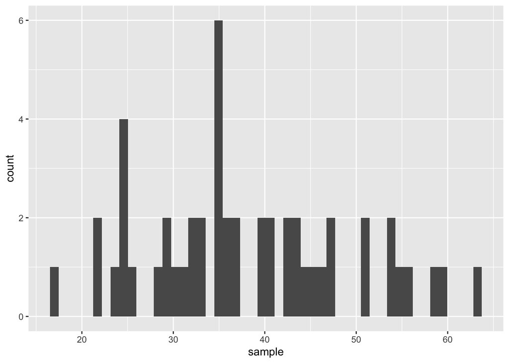

```r
ggplot(pmap_ex[[2]], aes(x=sample))+
  geom_histogram(bins = 50)
```

### Nesting and combining map functions

The Purrr functions can also be used in combination with other Tidyverse packages and functions. Example 6 uses the *map* function within *mutate* to add a linear model using the *lm* function to every “crop_type” in our farm data. Before we can pass the data to *map*, the example also uses *nest* to convert the grouped dataframe into a list where the group is in the first column and the remaining columns from our original dataframe are “nested” into the second column of our list. The returned object adds the result of **lms** as a third column, which can be further cleaned up and *unnest*’ed for other applications.

**Example 6**

```r
farm_data_lms <- farm_data |>
  group_by(crop_type) |>
  nest() |>
  mutate(lms = map(data, ~lm(yield_tons ~ fertilizer_used_tons + pesticide_used_kg, data = .)))

farm_data_lms[[3]][1]
```

```
## [[1]]
##
## Call:
## lm(formula = yield_tons ~ fertilizer_used_tons + pesticide_used_kg,
##     data = .)
##
## Coefficients:
##          (Intercept)  fertilizer_used_tons     pesticide_used_kg
##               51.305                -2.207                -7.480
```

## Conclusion

The Purrr dataset is a great alternative to using *for* loops. One advantage is more human-friendly syntax that compresses multiple lines of code into an easier to ready format.

This tutorial only covers some of the most common functions of the *Purrr* package, but the package includes many more promising tools to make your R programming more efficient, including *walk*, *modify* and other *map* variants like *imap* and *map_if*. For more information, visit the [Purrr documentation](https://purrr.tidyverse.org/reference/map.html) or review the [Posit Purrr Cheatsheet](https://github.com/rstudio/cheatsheets/blob/main/purrr.pdf).